# HA_COVID_factors

### Sunlight

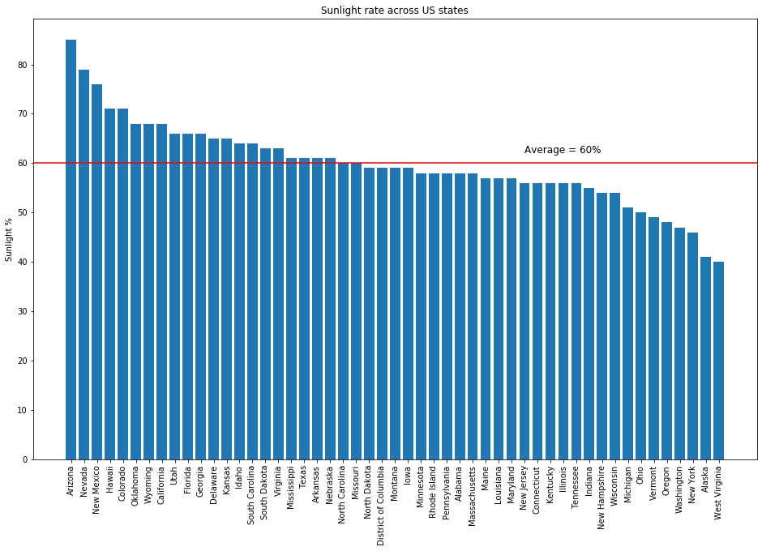

```python
sun_sorted = reg_tab.sort_values(['Sunlight'],ascending=False)

plt.figure(figsize=(16,10))
plt.bar(sun_sorted['Location'],sun_sorted['Sunlight'])
plt.axhline(60,color='red')
plt.xticks(rotation='vertical')
plt.ylabel('Sunlight %')
plt.title('Sunlight rate across US states')
plt.text(35, 62, 'Average = 60%', fontsize=12)
plt.show()
```

```python
fig = go.Figure(data=go.Choropleth(
    locations=reg_tab['Location_s'],
    z = reg_tab['Sunlight'],
    locationmode = 'USA-states',
    colorbar_title='%'))

fig.update_layout(
    title_text = 'Sunlight rate in US [%]',
    geo_scope='usa')

fig.show()
```

[interactive chart not shown]

### Uninsured sumary

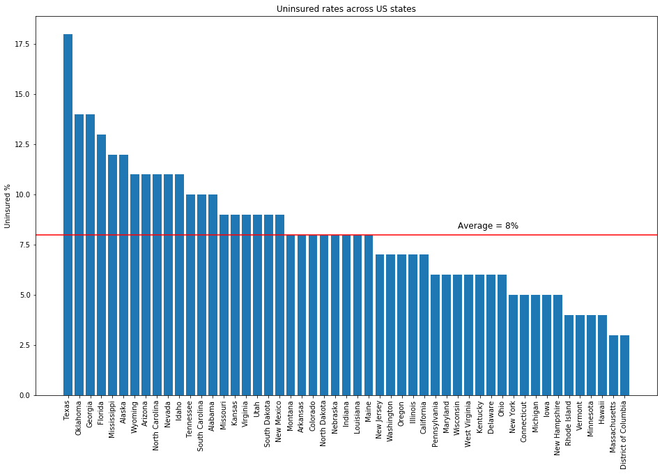

```python
uninsured_sorted = reg_tab.sort_values(['Uninsured'],ascending=False)

plt.figure(figsize=(16,10))
plt.bar(uninsured_sorted['Location'],uninsured_sorted['Uninsured'])
plt.axhline(8,color='red')
plt.xticks(rotation='vertical')
plt.ylabel('Uninsured %')
plt.title('Uninsured rates across US states')
plt.text(35, 8.3, 'Average = 8%', fontsize=12)
plt.show()
```

```python
fig = go.Figure(data=go.Choropleth(
    locations=reg_tab['Location_s'],
    z = reg_tab['Uninsured'],
    locationmode = 'USA-states',
    colorbar_title='%'))

fig.update_layout(
    title_text = 'Uninsured rate [%]',
    geo_scope='usa')

fig.show()
```

[interactive chart not shown]

## Analysis I - Linear Regression

```python
reg_tab=res[lm_cols][1:]

# Transforming to percentage units
reg_tab['Gender-Male']=reg_tab['Male']*100/reg_tab['Total']
reg_tab['65+']=reg_tab['65+']*100/reg_tab['Total']
reg_tab['White']=reg_tab['White']*100/reg_tab['Total']
reg_tab['Black']=reg_tab['Black']*100/reg_tab['Total']
reg_tab['Hispanic']=reg_tab['Hispanic']*100/reg_tab['Total']
reg_tab['Asian']=reg_tab['Asian']*100/reg_tab['Total']
reg_tab['Islander']=reg_tab['Islander']*100/reg_tab['Total']
reg_tab['Adults_Alcohol']=reg_tab['Adults_Alcohol']*100/reg_tab['Total']
reg_tab['Adults 55-64']=reg_tab['Adults 55-64']*100/reg_tab['Total']
reg_tab['Adults_Hypertension']=reg_tab['Adults_Hypertension']*100
reg_tab['Adults_Arthrisis']=reg_tab['Adults_Arthrisis']*100
reg_tab['Adults_Asthma']=reg_tab['Adults_Asthma']*100
reg_tab['Adults_Diabetes']=reg_tab['Adults_Diabetes']*100
reg_tab['Adults_FluShot']=reg_tab['Adults_FluShot']*100
reg_tab['Adults_CardioV']=reg_tab['Adults_CardioV']*100
reg_tab['Adults_Obese']=reg_tab['Adults_Obese']*100
reg_tab['Adults_Smoke']=reg_tab['Adults_Smoke']*100
reg_tab['Mental Health']=reg_tab['Mental Health']*100
reg_tab['Uninsured']=reg_tab['Uninsured']*100

#Dropping factors not selected for analysis and to avoid multicollinearity
reg_tab=reg_tab.drop(['Total','Male','Female','Children 0-18','Adults 19-25', 'Adults 26-34','Adults 35-54','Adults 55-64'],axis=1)
```

```python
# Selecting dependent/independent set of columns
variables = [col for col in reg_tab.columns if col not in ['Deaths', 'Location']]

# Linear regression model
ols_mod = smi.OLS(reg_tab['Deaths'], reg_tab[variables]).fit()
```

```python
# Results summary diagnostics
ols_mod.summary2().tables[0]
```

|  | 0 | 1 | 2 | 3 |
| --- | --- | --- | --- | --- |
| 0 | Model: | OLS | Adj. R-squared (uncentered): | 0.354 |
| 1 | Dependent Variable: | Deaths | AIC: | 757.8338 |
| 2 | Date: | 2020-06-24 15:54 | BIC: | 798.4021 |
| 3 | No. Observations: | 51 | Log-Likelihood: | -357.92 |
| 4 | Df Model: | 21 | F-statistic: | 2.328 |
| 5 | Df Residuals: | 30 | Prob (F-statistic): | 0.0168 |
| 6 | R-squared (uncentered): | 0.620 | Scale: | 1.2408e+05 |

```python
tab_all = ols_mod.summary2().tables[1]
tab_all.style.background_gradient(cmap='seismic', subset=pd.IndexSlice[tab_all['P>|t|']<.05, 'P>|t|']).format({'Coef.': "{:,.02f}",'Std.Err.': "{:,.2f}",'t': "{:,.2f}",'[0.025': "{:,.2f}",'0.975]': "{:,.2f}",'P>|t|': "{:,.2f}"})
```

|  | Coef. | Std.Err. | t | P>\|t\| | [0.025 | 0.975] |
| --- | --- | --- | --- | --- | --- | --- |
| 65+ | 77.67 | 55.48 | 1.40 | 0.17 | -35.65 | 190.98 |
| White | -26.65 | 19.08 | -1.40 | 0.17 | -65.62 | 12.32 |
| Black | -5.02 | 18.07 | -0.28 | 0.78 | -41.92 | 31.89 |
| Hispanic | -35.46 | 23.98 | -1.48 | 0.15 | -84.43 | 13.50 |
| Asian | 39.17 | 44.86 | 0.87 | 0.39 | -52.45 | 130.79 |
| Islander | -369.12 | 149.56 | -2.47 | 0.02 | -674.55 | -63.69 |
| Adults_Alcohol | -145.30 | 97.22 | -1.49 | 0.15 | -343.85 | 53.26 |
| Adults_Arthrisis | -85.86 | 55.92 | -1.54 | 0.14 | -200.07 | 28.35 |
| Adults_Asthma | 42.90 | 103.90 | 0.41 | 0.68 | -169.30 | 255.10 |
| Adults_Diabetes | 7.69 | 117.79 | 0.07 | 0.95 | -232.88 | 248.26 |
| Adults_FluShot | -36.26 | 15.07 | -2.41 | 0.02 | -67.03 | -5.50 |
| Adults_CardioV | 173.94 | 107.22 | 1.62 | 0.12 | -45.04 | 392.91 |
| Adults_Obese | -17.13 | 33.76 | -0.51 | 0.62 | -86.08 | 51.82 |
| Adults_Smoke | -34.13 | 51.90 | -0.66 | 0.52 | -140.12 | 71.87 |
| Adults_Hypertension | -42.81 | 44.91 | -0.95 | 0.35 | -134.53 | 48.91 |
| Mental Health | 11.79 | 20.58 | 0.57 | 0.57 | -30.24 | 53.81 |
| Med Expend per cap | -0.02 | 0.11 | -0.13 | 0.89 | -0.24 | 0.21 |
| Median family income | -0.02 | 0.01 | -1.43 | 0.16 | -0.04 | 0.01 |
| Sunlight | -13.09 | 12.51 | -1.05 | 0.30 | -38.64 | 12.46 |
| Uninsured | -47.39 | 31.37 | -1.51 | 0.14 | -111.46 | 16.69 |
| Gender-Male | 177.86 | 68.98 | 2.58 | 0.02 | 36.97 | 318.74 |

Coefficients sorted according to their magnitude (Coef.)

```python
tab=ols_mod.summary2().tables[1][['Coef.','P>|t|']].sort_values('Coef.')
tab.style.background_gradient(cmap='Greys', axis=0, subset=pd.IndexSlice[tab['P>|t|']<.05, 'P>|t|']).background_gradient(cmap=c, axis=0, subset=pd.IndexSlice['Coef.']).format({'Coef.': "{:,.02f}",'P>|t|': "{:,.2f}"})
```

|  | Coef. | P>\|t\| |
| --- | --- | --- |
| Islander | -369.12 | 0.02 |
| Adults_Alcohol | -145.30 | 0.15 |
| Adults_Arthrisis | -85.86 | 0.14 |
| Uninsured | -47.39 | 0.14 |
| Adults_Hypertension | -42.81 | 0.35 |
| Adults_FluShot | -36.26 | 0.02 |
| Hispanic | -35.46 | 0.15 |
| Adults_Smoke | -34.13 | 0.52 |
| White | -26.65 | 0.17 |
| Adults_Obese | -17.13 | 0.62 |
| Sunlight | -13.09 | 0.30 |
| Black | -5.02 | 0.78 |
| Median family income | -0.02 | 0.16 |
| Med Expend per cap | -0.02 | 0.89 |
| Adults_Diabetes | 7.69 | 0.95 |
| Mental Health | 11.79 | 0.57 |
| Asian | 39.17 | 0.39 |
| Adults_Asthma | 42.90 | 0.68 |
| 65+ | 77.67 | 0.17 |
| Adults_CardioV | 173.94 | 0.12 |
| Gender-Male | 177.86 | 0.02 |

Coefficients sorted according to their statistical significance (P>|t|).

```python
tab_all=ols_mod.summary2().tables[1][['Coef.','P>|t|']].sort_values('P>|t|')
tab_all.style.background_gradient(cmap=c, axis=0, subset=pd.IndexSlice['P>|t|']).format({'Coef.': "{:,.02f}",'P>|t|': "{:,.2f}"})
```

|  | Coef. | P>\|t\| |
| --- | --- | --- |
| Gender-Male | 177.86 | 0.02 |
| Islander | -369.12 | 0.02 |
| Adults_FluShot | -36.26 | 0.02 |
| Adults_CardioV | 173.94 | 0.12 |
| Adults_Arthrisis | -85.86 | 0.14 |
| Uninsured | -47.39 | 0.14 |
| Adults_Alcohol | -145.30 | 0.15 |
| Hispanic | -35.46 | 0.15 |
| Median family income | -0.02 | 0.16 |
| 65+ | 77.67 | 0.17 |
| White | -26.65 | 0.17 |
| Sunlight | -13.09 | 0.30 |
| Adults_Hypertension | -42.81 | 0.35 |
| Asian | 39.17 | 0.39 |
| Adults_Smoke | -34.13 | 0.52 |
| Mental Health | 11.79 | 0.57 |
| Adults_Obese | -17.13 | 0.62 |
| Adults_Asthma | 42.90 | 0.68 |
| Black | -5.02 | 0.78 |
| Med Expend per cap | -0.02 | 0.89 |
| Adults_Diabetes | 7.69 | 0.95 |

Miscellaneous factors

```python
tab.loc[['Uninsured','Sunlight','Median family income','Med Expend per cap','65+','Gender-Male'],:].sort_values('Coef.').style.background_gradient(cmap='Reds_r', axis=0, subset=pd.IndexSlice[tab['P>|t|']<.05, 'P>|t|']).background_gradient(cmap=c, axis=0, subset=pd.IndexSlice['Coef.']).format({'Coef.': "{:,.02f}",'P>|t|': "{:,.2f}"})
```

|  | Coef. | P>\|t\| |
| --- | --- | --- |
| Uninsured | -47.39 | 0.14 |
| Sunlight | -13.09 | 0.30 |
| Median family income | -0.02 | 0.16 |
| Med Expend per cap | -0.02 | 0.89 |
| 65+ | 77.67 | 0.17 |
| Gender-Male | 177.86 | 0.02 |

Disease related factors

```python
tab.loc[['Adults_Alcohol','Adults_Arthrisis','Adults_Asthma','Adults_Diabetes','Adults_FluShot','Adults_CardioV','Adults_Obese','Adults_Smoke','Adults_Hypertension','Mental Health'],:].sort_values('Coef.').style.background_gradient(cmap='Reds_r', axis=0, subset=pd.IndexSlice[tab['P>|t|']<.05, 'P>|t|']).background_gradient(cmap=c, axis=0, subset=pd.IndexSlice['Coef.']).format({'Coef.': "{:,.02f}",'P>|t|': "{:,.2f}"})
```

|  | Coef. | P>\|t\| |
| --- | --- | --- |
| Adults_Alcohol | -145.30 | 0.15 |
| Adults_Arthrisis | -85.86 | 0.14 |
| Adults_Hypertension | -42.81 | 0.35 |
| Adults_FluShot | -36.26 | 0.02 |
| Adults_Smoke | -34.13 | 0.52 |
| Adults_Obese | -17.13 | 0.62 |
| Adults_Diabetes | 7.69 | 0.95 |
| Mental Health | 11.79 | 0.57 |
| Adults_Asthma | 42.90 | 0.68 |
| Adults_CardioV | 173.94 | 0.12 |

Ethnic related factors

```python
tab.loc[['White', 'Black', 'Hispanic','Asian','Islander'],:].sort_values('Coef.').style.background_gradient(cmap='Reds_r', axis=0, subset=pd.IndexSlice[tab['P>|t|']<.05, 'P>|t|']).background_gradient(cmap=c, axis=0, subset=pd.IndexSlice['Coef.']).format({'Coef.': "{:,.02f}",'P>|t|': "{:,.2f}"})
```

|  | Coef. | P>\|t\| |
| --- | --- | --- |
| Islander | -369.12 | 0.02 |
| Hispanic | -35.46 | 0.15 |
| White | -26.65 | 0.17 |
| Black | -5.02 | 0.78 |
| Asian | 39.17 | 0.39 |

## Analysis II - Machine Learning K-Means clustering algorithm

We use unsupervised machine learning algorithm, K-Means, to cluster state in different groups.

#### Finding optimal parameter k - hyperparameter tuning

Choosing best k parameter based on inertia (sum of least squares to the clusters' centroids)

```python
# Variables selection
nvars=variables+['Deaths']

# Search for optimal k based on inertia metric (Sum of squared distances)
ssd=[]
K=range(2,25)
for k in K:
    km = KMeans(n_clusters=k)
    km = km.fit(reg_tab[nvars])
    ssd.append(km.inertia_)
```

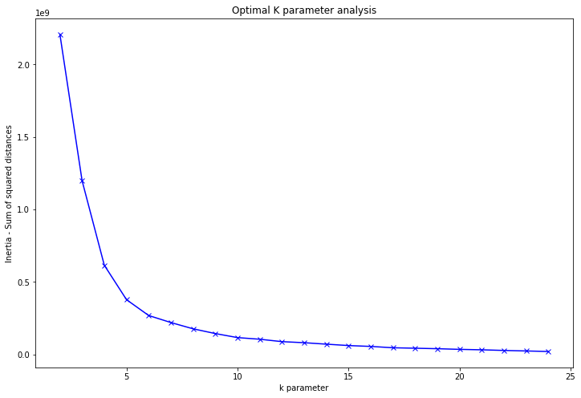

```python
plt.figure(figsize=(12,8))
plt.plot(K, ssd, 'bx-')
plt.xlabel('k parameter')
plt.ylabel('Inertia - Sum of squared distances')
plt.title('Optimal K parameter analysis')
plt.show()
```

We see that the "elbow" break occurred at k=5, therefore we will choose it for our further analysis.

#### K-Means with optimal parameter and tabular results

```python
km = KMeans(n_clusters=5, random_state=7, max_iter=1000)
km.fit(reg_tab[nvars])
```

```
KMeans(algorithm='auto', copy_x=True, init='k-means++', max_iter=1000,
       n_clusters=5, n_init=10, n_jobs=None, precompute_distances='auto',
       random_state=7, tol=0.0001, verbose=0)
```

```python
#Clusters and their factors' properties
x=pd.DataFrame(nvars)

# Adding unit description
x.iloc[0:15]+=' [%]'
x.iloc[15:17]+=' [USD]'
x.iloc[17:21]+=' [%]'

# Adding clusters' propeties columns
x['1']=km.cluster_centers_[0]
x['2']=km.cluster_centers_[1]
x['3']=km.cluster_centers_[2]
x['4']=km.cluster_centers_[3]
x['5']=km.cluster_centers_[4]


# Adding column names
x=x.rename(columns={0:'Factors','1':'Cluster G','2':'Cluster P','3':'Cluster O','4':'Cluster Y','5':'Cluster B'}).set_index('Factors')

#Min, max and Mean for every factor to compare among clusters
max=pd.DataFrame(x.idxmax(axis=1)).rename(columns={0:'Max'})
min=pd.DataFrame(x.idxmin(axis=1)).rename(columns={0:'Min'})
mean=pd.DataFrame(x.mean(axis=1)).rename(columns={0:'Mean'})

# Building dataframe with min, max, mean columns
x=x.join(max).join(min).join(mean)

#Reordering of columns with decreasing death toll
x=x[['Cluster G','Cluster O','Cluster B','Cluster P','Cluster Y','Max','Min','Mean']]
#color palette for dataframe
cm = sns.light_palette("lightgreen", as_cmap=True) #lightgray

x.style.background_gradient(cmap=cm, axis=1, subset=pd.IndexSlice[:, ['Cluster G','Cluster O','Cluster B','Cluster P','Cluster Y']]).format({'Cluster G': "{:,.2f}",'Cluster P': "{:,.2f}",'Cluster O': "{:,.2f}",'Cluster Y': "{:,.2f}",'Cluster B': "{:,.2f}",'Mean': "{:,.0f}"})
```

[output not shown]

Describe every group and name clusters based on properties specificity:

- #### Cluster G - death highest - diseases lowest, so treat it inversely, all lowest factors responsible - Deadly group highest: deaths, hispanic, alcohol, flu vaccination rate  
  lowest: 65+, Arthrisis, Diabetes, cardiov, hypertension, sunlight
- #### Cluster O - wealthy asian group highest: 65+, Asian, Islander, Med exp, Median income  
  lowest: white, obese, smoke, uninsured
- #### Cluster B - southern uninsured group highest: sunlight, uninsured  
  lowest: asthma, flu shot, mental
- #### Cluster P - Diseasesfull group highest: Black, arthrisis, asthma, Cardiovascular, obese, smoke, hypertension, mental  
  lowest: asian, islander, alcohol, med exp, median income, males
- #### Cluster Y - Immune males group highest: male, white  
  lowest: black, hispanic, deaths

#### Map visualisation of cluster's location

```python
# Build usmap dataframe for map visualisation
states = {'Alabama': 'AL','Alaska': 'AK','American Samoa': 'AS','Arizona': 'AZ','Arkansas': 'AR','California': 'CA','Colorado': 'CO','Connecticut': 'CT','Delaware': 'DE','District of Columbia': 'DC','Florida': 'FL','Georgia': 'GA','Guam': 'GU','Hawaii': 'HI','Idaho': 'ID','Illinois': 'IL','Indiana': 'IN','Iowa': 'IA','Kansas': 'KS','Kentucky': 'KY','Louisiana': 'LA','Maine': 'ME','Maryland': 'MD','Massachusetts': 'MA','Michigan': 'MI','Minnesota': 'MN','Mississippi': 'MS','Missouri': 'MO','Montana': 'MT','Nebraska': 'NE','Nevada': 'NV','New Hampshire': 'NH','New Jersey': 'NJ','New Mexico': 'NM','New York': 'NY','North Carolina': 'NC','North Dakota': 'ND','Northern Mariana Islands':'MP','Ohio': 'OH','Oklahoma': 'OK','Oregon': 'OR','Pennsylvania': 'PA','Puerto Rico': 'PR','Rhode Island': 'RI','South Carolina': 'SC','South Dakota': 'SD','Tennessee': 'TN','Texas': 'TX','Utah': 'UT','Vermont': 'VT','Virgin Islands': 'VI','Virginia': 'VA','Washington': 'WA','West Virginia': 'WV','Wisconsin': 'WI','Wyoming': 'WY'}
reg_tab['Location_s']=reg_tab['Location'].map(states)
usmap=reg_tab[['Location_s','Location']].reset_index()[['Location_s','Location']].join(pd.DataFrame(km.labels_)).rename(columns={0:'Cluster'})


# Map of K-Means clustering

fig = go.Figure(data=go.Choropleth(
    locations=usmap['Location_s'], # Spatial coordinates
    z = km.labels_.astype(str), # Data to be color-coded
    locationmode = 'USA-states', # set of locations match entries in `locations`
    colorscale = ['#7fc97f','#beaed4','#fdc086','#ffff99','#386cb0'],
    #colorbar=dict(tickvals=[0,1,2,3,4], ticktext=['Cluster G','Cluster P','Cluster O','Cluster Y','Cluster B']),
    hovertext=usmap['Location'],
    showscale=False
))

fig.update_layout(
    title_text = 'K-Means clustering map',
    geo_scope='usa', # limite map scope to USA
)

fig.show()


# Map of COVID deaths

reg_tab['Deaths']


fig = go.Figure(data=go.Choropleth(
    locations=usmap['Location_s'], # Spatial coordinates
    z = reg_tab[reg_tab['Location']!='New York']['Deaths'],# Al states w/t NY cause skewed the color scale
    locationmode = 'USA-states', # set of locations match entries in `locations`
    colorscale = 'PuRd',
    colorbar_title = "Death number",
))

fig.update_layout(
    title_text = 'COVID Deaths map',
    geo_scope='usa', # limite map scope to USA
)

fig.show()
```

[interactive chart not shown]

We see that the COVID Deaths map shows some similarities with the cluster map. Therefore, we can conclude that clustering had been somehow related to death factor.

```python
#cm = sns.light_palette("lightgreen", as_cmap=True) #lightgray
#reg_tab.corr().style.background_gradient(cmap=cm,axis=0).format({'1': "{:,.2f}",'2': "{:,.2f}",'3': "{:,.2f}",'4': "{:,.2f}",'5': "{:,.2f}"})
```